# 2.0 RNA-seq pipeline comparison — HISAT2 (OLD) vs STAR-v2 PAR-aware (NEW) counts (A549 + HT1080)

# Why this notebook exists

The HT1080 and A549 cell lines were each sequenced once, but the FASTQ files have been **re-quantified through two different upstream pipelines** at different points in the project. Per-cell-line analyses (2.1.1 A549, 2.2.1 HT1080) all use the **NEW** counts; older reports (in `data/RNAseq/AUG_13_2025_LOY_A549_HT1080/`) use the **OLD** counts. This notebook asks: **how comparable are the two count tables, and would the biological conclusions change if we’d kept the OLD counts?**

The “NEW” pipeline here is the current canonical one used by every downstream analysis (2.1.1 A549, 2.2.1 HT1080, 2.3.1 LNCaP): the **PAR-aware STAR v2 realignment** (`STAR_v2_PARfix/`). The interim non-PAR-aware STAR run (`STAR_v1/`) that briefly served as “NEW” between HISAT2 and the PAR-aware run is no longer in use; PAR1/PAR2 genes (SHOX, CSF2RA, SLC25A6, AKAP17A, …) were silently dropped at multi-mapper filtering in that interim run and are now recovered. Only HISAT2 (OLD) vs PAR-aware STAR (NEW) are compared here.

## Pipeline difference summary

| Field | OLD pipeline | NEW pipeline |
| --- | --- | --- |
| Counts dir | `data/RNAseq/AUG_13_2025_LOY_A549_HT1080/counts/` | `projects/RNAseq/counts/STAR_v2_PARfix/AUG_2025_<cell>_LOY/` |
| Aligner | HISAT2 (default) | STAR two-pass, PAR-Y-masked reference |
| chrY handling | standard | Y chromosome PAR regions hard-masked so chrX-PAR reads are no longer split between two equivalent positions |
| Reference annotation | GENCODE v47 (`chr_patch_hapl_scaff`) | GENCODE v49 (primary assembly) |
| featureCounts | v2.0.1 | v2.1.1 |
| Sample composition | identical (9 HT1080 + 11 A549) | identical |

# 1. Setup

# 2. Load count tables

```
## HT1080 OLD: 86402 genes x 9 samples
```

```
## HT1080 NEW: 78899 genes x 9 samples
```

```
## A549  OLD: 86402 genes x 11 samples
```

```
## A549  NEW: 78899 genes x 11 samples
```

# 3. Library sizes by pipeline

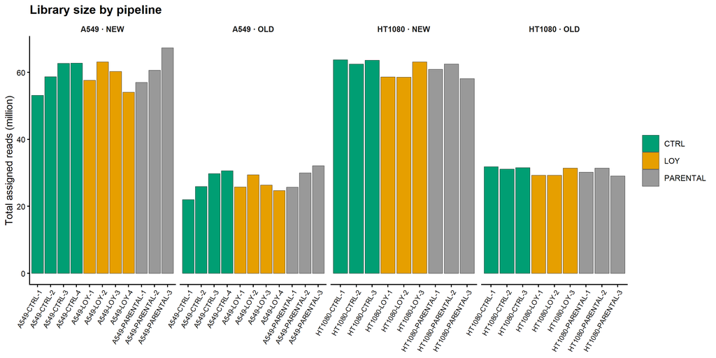

```
## Saved: libsize_by_pipeline.(png|pdf)
```

Per-cell-line library size: OLD vs NEW

| cell | mean_OLD_M | mean_NEW_M | mean_rel_diff |
| --- | --- | --- | --- |
| A549 | 27.526 | 59.786 | 1.182 |
| HT1080 | 30.604 | 61.341 | 1.004 |

# 4. Gene-ID harmonization + filtering

The OLD pipeline annotated with GENCODE v47, NEW with v49. Both produce Ensembl IDs like `ENSG00000123456.18` (with version suffix). The integer ENSG accession is stable across versions; the suffix changes when the gene’s annotation is updated. We harmonize by stripping the suffix and intersecting on the accession.

```
## --- HT1080 ----------------------------------------
```

```
##   OLD-unique ENSG: 7527
```

```
##   NEW-unique ENSG: 24
```

```
##   Shared ENSG:     78875
```

```
## --- A549 ------------------------------------------
```

```
##   OLD-unique ENSG: 7527
```

```
##   NEW-unique ENSG: 24
```

```
##   Shared ENSG:     78875
```

## 4.1 Filter + TMM normalize each pipeline independently

```
## HT1080 OLD kept after CPM filter: 17085 genes
```

```
## HT1080 NEW kept after CPM filter: 16020 genes
```

```
## A549   OLD kept after CPM filter: 17623 genes
```

```
## A549   NEW kept after CPM filter: 16145 genes
```

# 5. Per-sample correlation: OLD vs NEW (same sample, two pipelines)

For each biological sample, compute Pearson correlation of logCPM between the OLD and NEW pipelines on the intersection of kept genes.

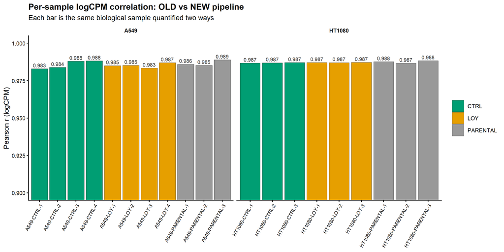

```
## Saved: per_sample_correlation_OLD_vs_NEW.(png|pdf)
```

Cross-pipeline correlation summary

| cell | median_pearson | min_pearson | median_spearman |
| --- | --- | --- | --- |
| A549 | 0.9853 | 0.9830 | 0.9858 |
| HT1080 | 0.9871 | 0.9867 | 0.9874 |

# 6. Per-gene mean expression scatter

For each cell line, mean logCPM per gene across all samples in OLD vs the same gene’s mean across all samples in NEW. Identity line for reference.

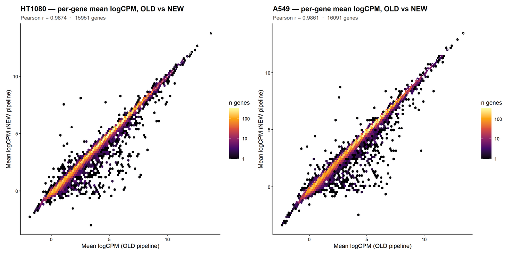

```
## Saved: per_gene_mean_scatter_OLD_vs_NEW.(png|pdf)
```

# 7. Sample correlation heatmap (concatenated OLD + NEW)

Concatenate OLD and NEW logCPM matrices for each cell line and cluster all samples together. Same biological sample under two pipelines should cluster together — and if pipeline effects dominate biology, we’d see OLD vs NEW samples cluster by pipeline instead.

```
## Saved: sample_cor_heatmap_HT1080.(png|pdf)
```

```
## Saved: sample_cor_heatmap_A549.(png|pdf)
```

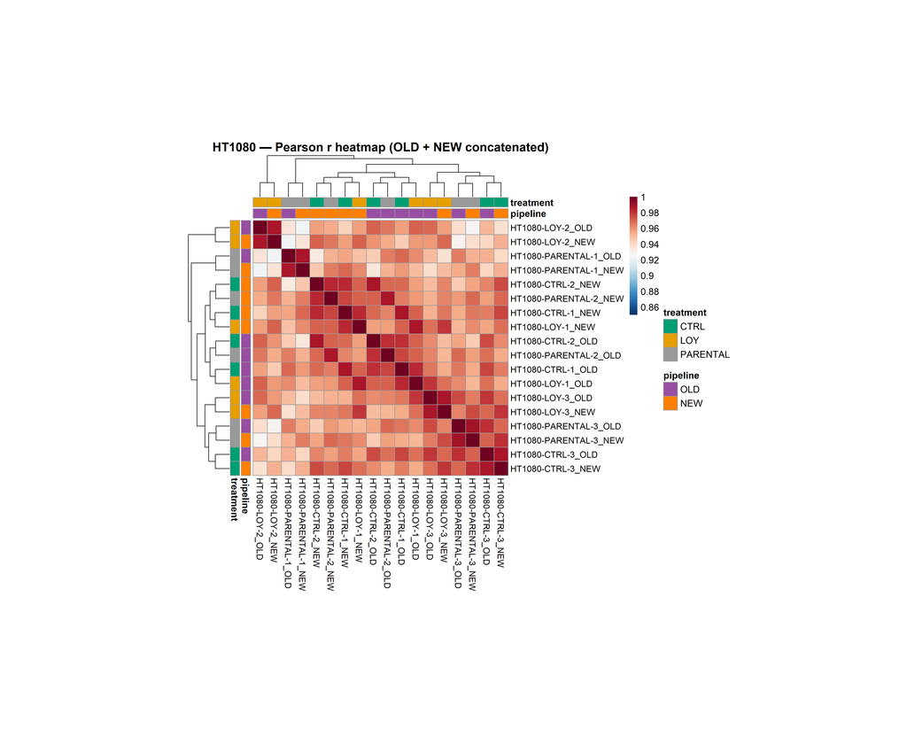

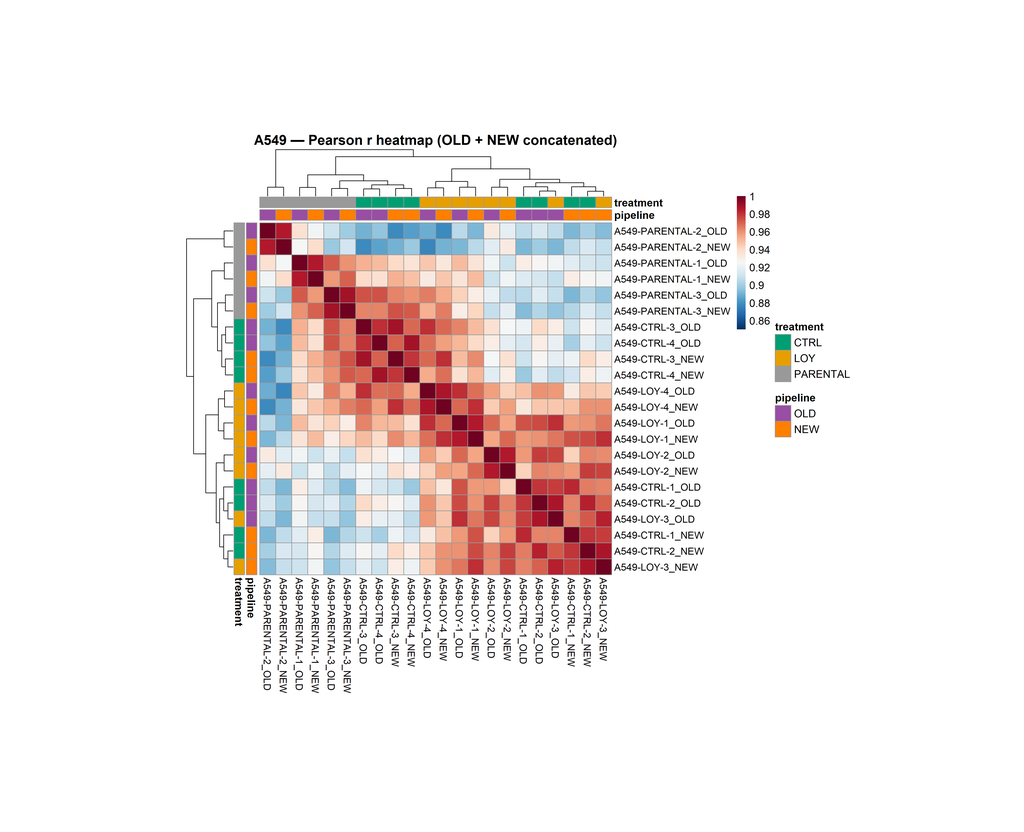

# 8. Differential expression on OLD vs NEW: do the conclusions change?

Three contrasts run on each pipeline’s counts:

1. **Paired** LOY vs sgCTRL (`~ 0 + treatment + passage`) — canonical
2. **Unpaired** LOY vs sgCTRL (`~ 0 + treatment`) — passage drift not modeled
3. **Pooled** LOY vs (PARENTAL + sgCTRL) — combined Y+ baseline, n=6 vs n=3 (HT1080) or n=7 vs n=4 (A549)

Identical underlying biology under both pipelines → high logFC correlation and substantial DEG overlap regardless of which contrast we pick.

DE concordance: OLD vs NEW pipeline across three contrast types

| cell | contrast | sig_OLD | sig_NEW | intersect | jaccard | lfc_r |
| --- | --- | --- | --- | --- | --- | --- |
| HT1080 | LOY vs sgCTRL (paired) | 621 | 578 | 551 | 0.8503 | 0.9850 |
| HT1080 | LOY vs sgCTRL (unpaired) | 65 | 66 | 61 | 0.8714 | 0.9856 |
| HT1080 | LOY vs pooled Y+ | 92 | 91 | 83 | 0.8300 | 0.9885 |
| A549 | LOY vs sgCTRL (paired) | 11 | 9 | 9 | 0.8182 | 0.9753 |
| A549 | LOY vs sgCTRL (unpaired) | 9 | 8 | 8 | 0.8889 | 0.9804 |
| A549 | LOY vs pooled Y+ | 10 | 7 | 7 | 0.7000 | 0.9889 |

## 8.1 Paired LOY vs sgCTRL — concordance

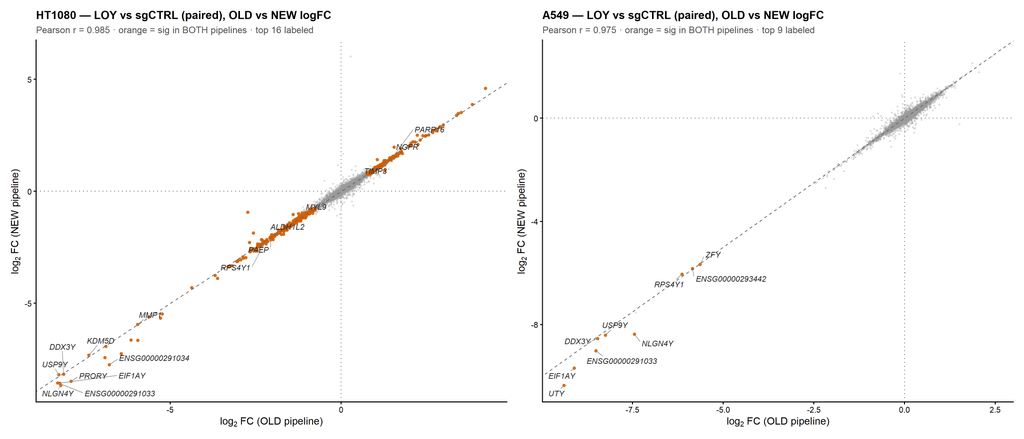

```
## Saved: lfc_concordance_paired.(png|pdf)
```

## 8.2 Unpaired LOY vs sgCTRL — concordance

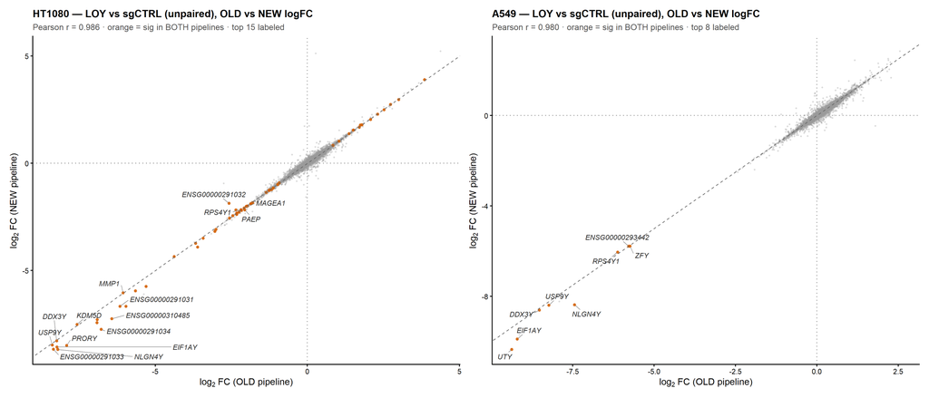

```
## Saved: lfc_concordance_unpaired.(png|pdf)
```

## 8.3 Pooled LOY vs Y+ — concordance

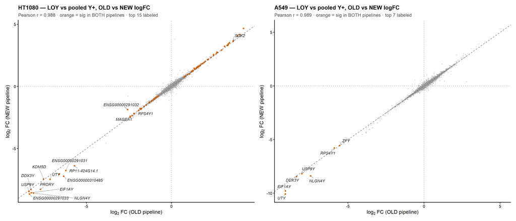

```
## Saved: lfc_concordance_pooled.(png|pdf)
```

# 9. GSEA — Hallmark NES concordance

Hallmark NES concordance: OLD vs NEW pipeline (50 pathways)

| cell | contrast | n_pathways | sig_OLD | sig_NEW | intersect | jaccard_sig | nes_r | sign_agree |
| --- | --- | --- | --- | --- | --- | --- | --- | --- |
| HT1080 | LOY vs sgCTRL (paired) | 50 | 19 | 19 | 19 | 1.000 | 0.973 | 0.96 |
| HT1080 | LOY vs sgCTRL (unpaired) | 50 | 12 | 9 | 9 | 0.750 | 0.918 | 0.92 |
| HT1080 | LOY vs pooled Y+ | 50 | 16 | 15 | 15 | 0.938 | 0.925 | 0.92 |
| A549 | LOY vs sgCTRL (paired) | 50 | 13 | 12 | 12 | 0.923 | 0.977 | 0.98 |
| A549 | LOY vs sgCTRL (unpaired) | 50 | 11 | 16 | 11 | 0.688 | 0.948 | 0.94 |
| A549 | LOY vs pooled Y+ | 50 | 23 | 26 | 23 | 0.885 | 0.985 | 0.98 |

## 9.1 Paired LOY vs sgCTRL — Hallmark NES

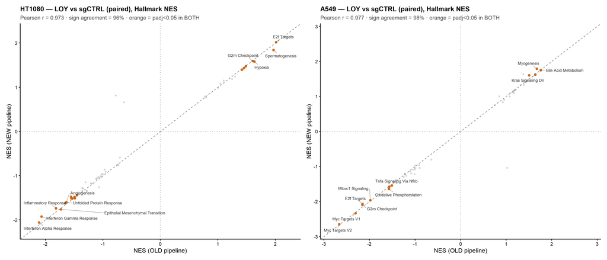

```
## Saved: gsea_concordance_paired.(png|pdf)
```

## 9.2 Unpaired LOY vs sgCTRL — Hallmark NES

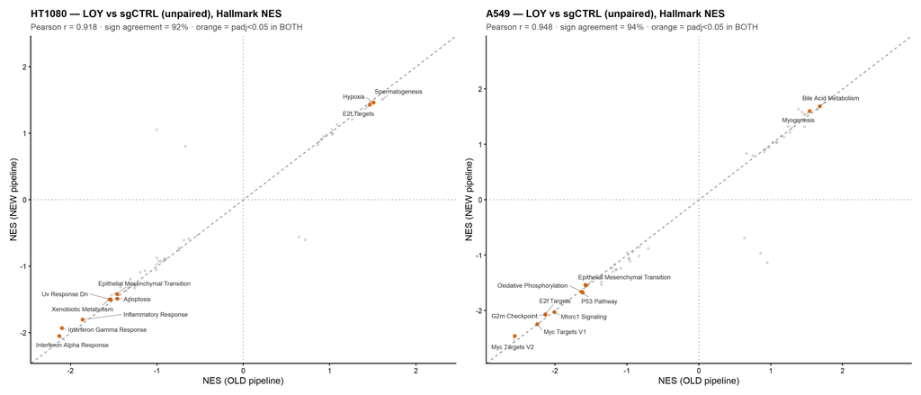

```
## Saved: gsea_concordance_unpaired.(png|pdf)
```

## 9.3 Pooled LOY vs Y+ — Hallmark NES

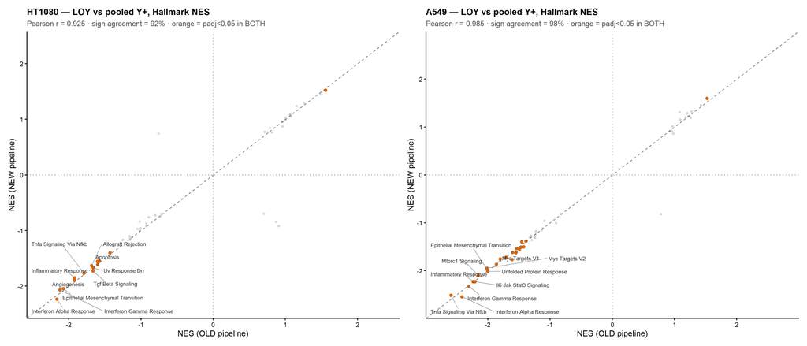

```
## Saved: gsea_concordance_pooled.(png|pdf)
```

# 10. TF regulons — CollecTRI activity concordance

Same idea, one layer up: feed the limma t-statistic (HGNC-keyed) for each of the 12 DE tables into `decoupleR::run_ulm()` against the CollecTRI regulon network. The result is a transcription-factor activity score per TF per contrast per pipeline; OLD vs NEW scores are scattered per contrast.

CollecTRI TF activity concordance: OLD vs NEW pipeline

| cell | contrast | n_tfs | sig_OLD | sig_NEW | intersect | jaccard_sig | score_r | sign_agree |
| --- | --- | --- | --- | --- | --- | --- | --- | --- |
| HT1080 | LOY vs sgCTRL (paired) | 635 | 144 | 144 | 137 | 0.907 | 0.988 | 0.965 |
| HT1080 | LOY vs sgCTRL (unpaired) | 635 | 102 | 99 | 90 | 0.811 | 0.982 | 0.959 |
| HT1080 | LOY vs pooled Y+ | 635 | 102 | 105 | 98 | 0.899 | 0.987 | 0.954 |
| A549 | LOY vs sgCTRL (paired) | 647 | 95 | 97 | 81 | 0.730 | 0.984 | 0.964 |
| A549 | LOY vs sgCTRL (unpaired) | 647 | 93 | 94 | 85 | 0.833 | 0.980 | 0.957 |
| A549 | LOY vs pooled Y+ | 647 | 119 | 112 | 100 | 0.763 | 0.987 | 0.946 |

## 10.1 Paired LOY vs sgCTRL — TF activity

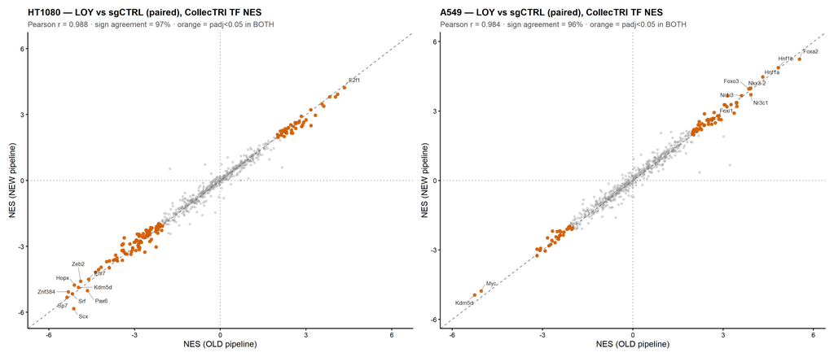

```
## Saved: tf_concordance_paired.(png|pdf)
```

## 10.2 Unpaired LOY vs sgCTRL — TF activity

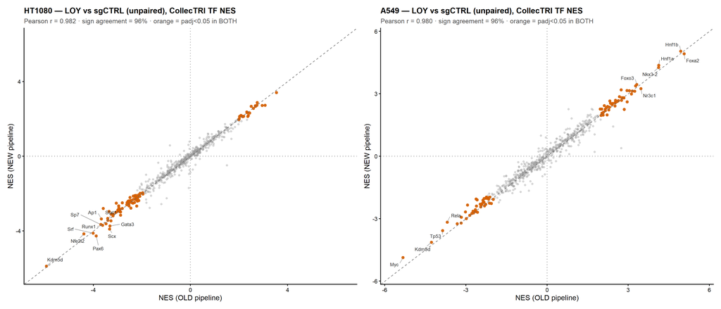

```
## Saved: tf_concordance_unpaired.(png|pdf)
```

## 10.3 Pooled LOY vs Y+ — TF activity

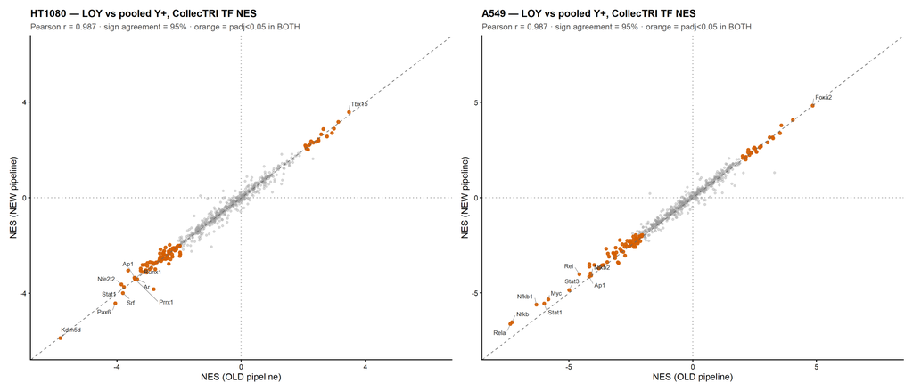

```
## Saved: tf_concordance_pooled.(png|pdf)
```

# 11. Verdict

```
## HT1080 · LOY vs sgCTRL (paired) CONCORDANT
##   Gene    OLD 621 | NEW 578 | intersect 551 (J 0.85) | logFC r = 0.985
##   GSEA    OLD 19 | NEW 19 | intersect 19 (J 1.00) | NES   r = 0.973  | sign 96%
##   TF      OLD 144 | NEW 144 | intersect 137 (J 0.91) | score r = 0.988  | sign 97%
##
## HT1080 · LOY vs sgCTRL (unpaired) CONCORDANT
##   Gene    OLD 65 | NEW 66 | intersect 61 (J 0.87) | logFC r = 0.986
##   GSEA    OLD 12 | NEW 9 | intersect 9 (J 0.75) | NES   r = 0.918  | sign 92%
##   TF      OLD 102 | NEW 99 | intersect 90 (J 0.81) | score r = 0.982  | sign 96%
##
## HT1080 · LOY vs pooled Y+       CONCORDANT
##   Gene    OLD 92 | NEW 91 | intersect 83 (J 0.83) | logFC r = 0.988
##   GSEA    OLD 16 | NEW 15 | intersect 15 (J 0.94) | NES   r = 0.925  | sign 92%
##   TF      OLD 102 | NEW 105 | intersect 98 (J 0.90) | score r = 0.987  | sign 95%
##
## A549 · LOY vs sgCTRL (paired)   CONCORDANT
##   Gene    OLD 11 | NEW 9 | intersect 9 (J 0.82) | logFC r = 0.975
##   GSEA    OLD 13 | NEW 12 | intersect 12 (J 0.92) | NES   r = 0.977  | sign 98%
##   TF      OLD 95 | NEW 97 | intersect 81 (J 0.73) | score r = 0.984  | sign 96%
##
## A549 · LOY vs sgCTRL (unpaired) CONCORDANT
##   Gene    OLD 9 | NEW 8 | intersect 8 (J 0.89) | logFC r = 0.980
##   GSEA    OLD 11 | NEW 16 | intersect 11 (J 0.69) | NES   r = 0.948  | sign 94%
##   TF      OLD 93 | NEW 94 | intersect 85 (J 0.83) | score r = 0.980  | sign 96%
##
## A549 · LOY vs pooled Y+         CONCORDANT
##   Gene    OLD 10 | NEW 7 | intersect 7 (J 0.70) | logFC r = 0.989
##   GSEA    OLD 23 | NEW 26 | intersect 23 (J 0.88) | NES   r = 0.985  | sign 98%
##   TF      OLD 119 | NEW 112 | intersect 100 (J 0.76) | score r = 0.987  | sign 95%
```